# Dehumanization X Columbus Day/Indigenous Peoples Day

Terrence Pope

2018-08-18

# Intro

This is a data set that includes the following variables:

| DH1_W_Responsible |
| --- |
| DH2_W_Civilized |
| DH3_W_Moral |
| DH4_W_Polite |
| DH5_W_Childlike |
| DH6_W_Rational |
| DH7_W_Warm |
| DH8_W_Agentic |
| DH9_W_Refined |
| DH10_W_Lacking_Culture |
| DH11_W_Lacking_Self-restraint |
| DH12_W_Instinctual |
| DH13_W_Mature |
| DH14_W_Stoic |
| DH15_W_Emotionally_Responsive |
| DH16_W_Cold |
| DH17_W_Open |
| DH18_W_Rigid |
| DH19_W_Passive |
| DH20_W_Superficial |
| DH1_N_Responsible |
| DH2_N_Civilized |
| DH3_N_Moral |
| DH4_N_Polite |
| DH5_N_Childlike |
| DH6_N_Rational |
| DH7_N_Warm |
| DH8_N_Agentic |
| DH9_N_Refined |
| DH10_N_Lacking_Culture |
| DH11_N_Lacking_Self-restraint |
| DH12_N_Instinctual |
| DH13_N_Mature |
| DH14_N_Stoic |
| DH15_N_Emotionally_Responsive |
| DH16_N_Cold |
| DH17_N_Open |
| DH18_N_Rigid |
| DH19_N_Passive |
| DH20_N_Superficial |
| No_Columbus |
| Create_IPD |
| BorninUS |
| LengthState |
| FatherUSBorn |
| MotherUSBorn |
| PrimaryCaretaker |
| PrimaryEd |
| SecondCaretaker |
| SecondEdu |
| Religion |
| Religiosity |
| College |
| Year |
| Education |
| LibCon |
| SES |
| Race |
| StateNumeric |
| LongestRegion |
| SubjectNumber |
| EMP_comp |
| IMP_comp |
| N_Uncivilized |
| White_Dehumanize |
| Native_Dehumanize |
| Age |

It’s primary focus is to look a bit more closely at the dehumaniztion variables and how they interact not only with one another, but with the dependent variables (Columbus Day/Indigenous Peoples’ Day (henceforth referred to as IPD)), as well as some of the demographic information gathered on the participants in this sample.

This sample comes from **Study Two**, so it is (*if I’m not mistaken*) a sample of participants gathered via *mturk*.

# Descriptives

First, lets take a look at a descriptives table of our variables. Keep in mind that some of the variables are categorical and are more difficult to interpret in a descriptives table.

|  | n | mean | sd | median | se |
| --- | --- | --- | --- | --- | --- |
| **DH1_W_Responsible** | 2811 | 61.24 | 21.82 | 62 | 0.4116 |
| **DH2_W_Civilized** | 2810 | 65.89 | 23.38 | 69 | 0.4411 |
| **DH3_W_Moral** | 2812 | 55.77 | 22.76 | 55 | 0.4292 |
| **DH4_W_Polite** | 2812 | 57.99 | 22.53 | 58 | 0.4248 |
| **DH5_W_Childlike** | 2809 | 40.76 | 24.49 | 43 | 0.462 |
| **DH6_W_Rational** | 2810 | 58.23 | 22.49 | 57 | 0.4243 |
| **DH7_W_Warm** | 2810 | 58.27 | 22.32 | 58 | 0.421 |
| **DH8_W_Agentic** | 2800 | 46.11 | 22.34 | 50 | 0.4222 |
| **DH9_W_Refined** | 2809 | 52.87 | 22.26 | 52 | 0.4199 |
| **DH10_W_Lacking_Culture** | 2808 | 46.34 | 27.71 | 50 | 0.523 |
| **DH11_W_Lacking_Self-restraint** | 2808 | 48.59 | 25.58 | 50 | 0.4828 |
| **DH12_W_Instinctual** | 2810 | 51.47 | 22.98 | 51 | 0.4335 |
| **DH13_W_Mature** | 2809 | 57.34 | 22.31 | 56 | 0.421 |
| **DH14_W_Stoic** | 2808 | 42.88 | 22.31 | 49 | 0.4209 |
| **DH15_W_Emotionally_Responsive** | 2812 | 59.98 | 22.77 | 60 | 0.4294 |
| **DH16_W_Cold** | 2810 | 44.74 | 23.99 | 49 | 0.4525 |
| **DH17_W_Open** | 2811 | 55.59 | 22.81 | 55 | 0.4302 |
| **DH18_W_Rigid** | 2807 | 49.6 | 23.27 | 50 | 0.4393 |
| **DH19_W_Passive** | 2810 | 45.16 | 23.21 | 49 | 0.4378 |
| **DH20_W_Superficial** | 2810 | 59.32 | 25.54 | 60 | 0.4818 |
| **DH1_N_Responsible** | 2807 | 63.86 | 21.06 | 64 | 0.3976 |
| **DH2_N_Civilized** | 2806 | 64.58 | 21.97 | 65 | 0.4147 |
| **DH3_N_Moral** | 2807 | 65.75 | 20.88 | 66 | 0.3941 |
| **DH4_N_Polite** | 2806 | 63.22 | 21.42 | 63 | 0.4044 |
| **DH5_N_Childlike** | 2802 | 29.22 | 22.26 | 25 | 0.4205 |
| **DH6_N_Rational** | 2807 | 61.61 | 21.17 | 61 | 0.3995 |
| **DH7_N_Warm** | 2804 | 61.05 | 22.07 | 60 | 0.4167 |
| **DH8_N_Agentic** | 2800 | 44.97 | 22.32 | 50 | 0.4219 |
| **DH9_N_Refined** | 2806 | 51.11 | 22.44 | 51 | 0.4235 |
| **DH10_N_Lacking_Culture** | 2804 | 23.9 | 23.15 | 17 | 0.4371 |
| **DH11_N_Lacking_Self-restraint** | 2805 | 34.44 | 23.39 | 33 | 0.4416 |
| **DH12_N_Instinctual** | 2807 | 61.3 | 23.48 | 61 | 0.4433 |
| **DH13_N_Mature** | 2806 | 65.15 | 20.69 | 65 | 0.3907 |
| **DH14_N_Stoic** | 2808 | 59.11 | 22.29 | 57 | 0.4206 |
| **DH15_N_Emotionally_Responsive** | 2806 | 54.38 | 24.29 | 53 | 0.4585 |
| **DH16_N_Cold** | 2805 | 35.19 | 22.8 | 35 | 0.4306 |
| **DH17_N_Open** | 2805 | 53.8 | 23.34 | 53 | 0.4406 |
| **DH18_N_Rigid** | 2807 | 45.41 | 23.89 | 50 | 0.451 |
| **DH19_N_Passive** | 2805 | 45.03 | 23.79 | 50 | 0.4492 |
| **DH20_N_Superficial** | 2805 | 30.41 | 22.87 | 27 | 0.4318 |
| **No_Columbus** | 2858 | 3.793 | 2.125 | 4 | 0.03976 |
| **Create_IPD** | 2858 | 4.481 | 1.956 | 4 | 0.03658 |
| **BorninUS*** | 2801 | 1.956 | 0.2041 | 2 | 0.003857 |
| **LengthState** | 2797 | 30.72 | 12.88 | 29 | 0.2435 |
| **FatherUSBorn*** | 2801 | 1.893 | 0.3352 | 2 | 0.006334 |
| **MotherUSBorn*** | 2801 | 1.882 | 0.3337 | 2 | 0.006306 |
| **PrimaryCaretaker*** | 2800 | 1.282 | 0.7601 | 1 | 0.01436 |
| **PrimaryEd** | 2801 | 2.988 | 1.225 | 3 | 0.02315 |
| **SecondCaretaker*** | 2801 | 2.828 | 1.114 | 3 | 0.02105 |
| **SecondEdu** | 2736 | 2.908 | 1.323 | 2 | 0.02529 |
| **Religion*** | 2799 | 2.45 | 1.674 | 2 | 0.03164 |
| **Religiosity** | 2800 | 3.632 | 2.235 | 4 | 0.04224 |
| **College*** | 2799 | 1.893 | 0.3094 | 2 | 0.005848 |
| **Year** | 300 | 3.363 | 1.631 | 3 | 0.09417 |
| **Education** | 2800 | 3.459 | 1.127 | 4 | 0.0213 |
| **LibCon** | 2799 | 4.401 | 1.713 | 4 | 0.03237 |
| **SES*** | 2801 | 1.538 | 0.4986 | 2 | 0.009422 |
| **Race*** | 2903 | 3.42 | 1.684 | 3 | 0.03125 |
| **StateNumeric*** | 2788 | 24.73 | 14.36 | 25 | 0.272 |
| **LongestRegion*** | 2789 | 4.425 | 2.104 | 5 | 0.03984 |
| **SubjectNumber** | 2903 | 1452 | 838.2 | 1452 | 15.56 |
| **EMP_comp** | 2841 | 3.337 | 1.438 | 3.4 | 0.02698 |
| **IMP_comp** | 2841 | 5.613 | 1.208 | 5.8 | 0.02266 |
| **N_Uncivilized** | 2811 | 2.277 | 1.33 | 2 | 0.02509 |
| **White_Dehumanize** | 2793 | 52.93 | 12.03 | 53.25 | 0.2275 |
| **Native_Dehumanize** | 2792 | 50.67 | 11.38 | 51.05 | 0.2153 |
| **Age** | 2793 | 38.72 | 13.33 | 35 | 0.2523 |

## Correlation of Civilized & Childlike for Natives

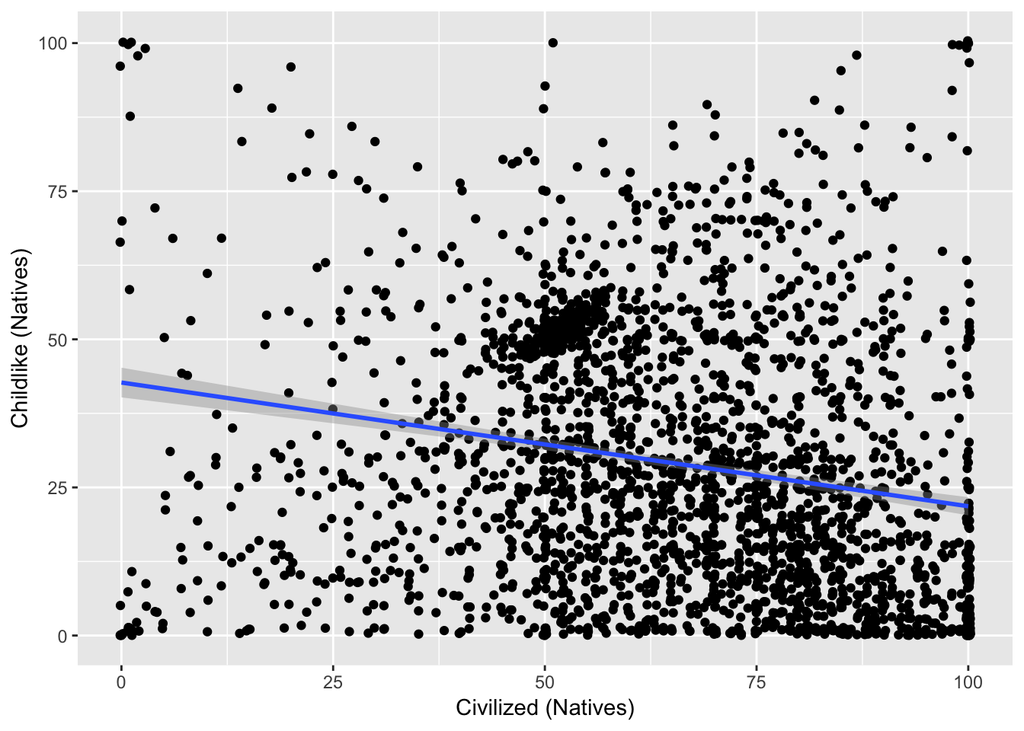

```
##
##  Pearson's product-moment correlation
##
## data:  dfdehumanDV$DH2_N_Civilized and dfdehumanDV$DH5_N_Childlike
## t = -11.141, df = 2800, p-value < 2.2e-16
## alternative hypothesis: true correlation is not equal to 0
## 95 percent confidence interval:
##  -0.2412194 -0.1702999
## sample estimates:
##        cor
## -0.2060302
```

At baseline the two seem to be somewhat negatively correlated with scores clustering around the Natives as Civilized and childlike.

## Correlation of External & Internal Motivation for Reducing Prejudice

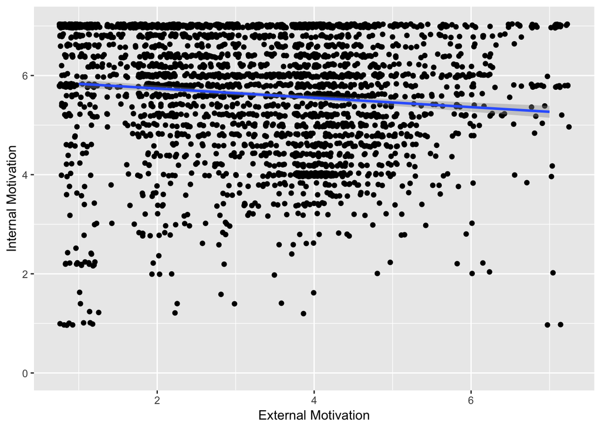

```
##
##  Pearson's product-moment correlation
##
## data:  dfdehumanDV$EMP_comp and dfdehumanDV$IMP_comp
## t = -6.006, df = 2839, p-value = 2.144e-09
## alternative hypothesis: true correlation is not equal to 0
## 95 percent confidence interval:
##  -0.14817440 -0.07554707
## sample estimates:
##        cor
## -0.1120103
```

Weakly negatively correlated but significant

## Dependent Variables: Columbus Day X EMP/IMP

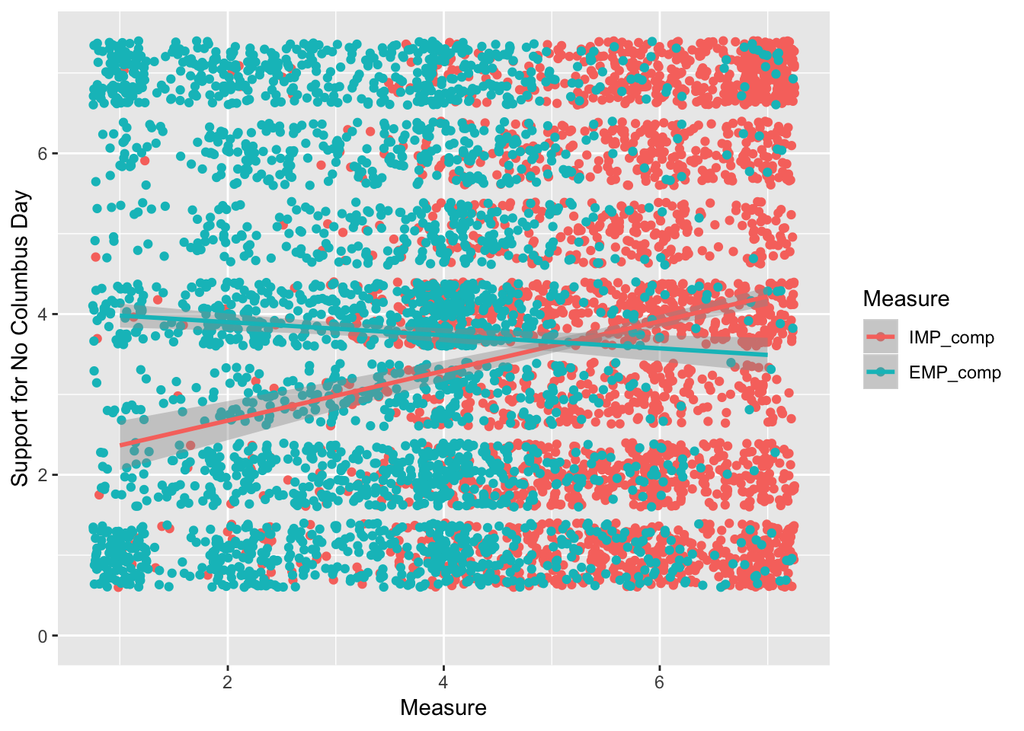

## Dependent Variables: Indigenous Peoples’ Day X EMP/IMP

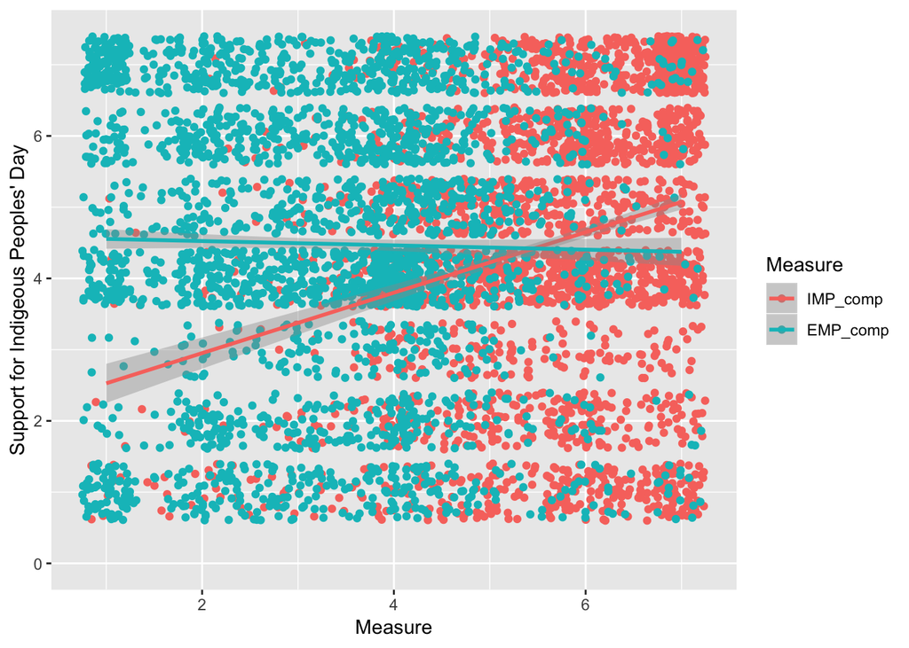

### Childlike X Columbus X IMP/EMP

[output not shown]

```
##
## Call:
## lm(formula = No_Columbus ~ scale(IMP_comp) + scale(EMP_comp) +
##     scale(DH5_N_Childlike) + scale(IMP_comp) * scale(EMP_comp) +
##     scale(IMP_comp) * scale(DH5_N_Childlike) + scale(IMP_comp) *
##     scale(EMP_comp) * scale(DH5_N_Childlike), data = dfdehumanDV)
##
## Residuals:
##     Min      1Q  Median      3Q     Max
## -3.6237 -1.8730 -0.0338  1.9000  4.5891
##
## Coefficients:
##                                                        Estimate Std. Error
## (Intercept)                                             3.76553    0.04041
## scale(IMP_comp)                                         0.38757    0.04136
## scale(EMP_comp)                                        -0.07850    0.04093
## scale(DH5_N_Childlike)                                  0.05469    0.04098
## scale(IMP_comp):scale(EMP_comp)                        -0.05507    0.03866
## scale(IMP_comp):scale(DH5_N_Childlike)                 -0.06879    0.03680
## scale(EMP_comp):scale(DH5_N_Childlike)                 -0.01434    0.03754
## scale(IMP_comp):scale(EMP_comp):scale(DH5_N_Childlike) -0.03704    0.02973
##                                                        t value Pr(>|t|)
## (Intercept)                                             93.180   <2e-16
## scale(IMP_comp)                                          9.371   <2e-16
## scale(EMP_comp)                                         -1.918   0.0552
## scale(DH5_N_Childlike)                                   1.334   0.1822
## scale(IMP_comp):scale(EMP_comp)                         -1.424   0.1544
## scale(IMP_comp):scale(DH5_N_Childlike)                  -1.869   0.0617
## scale(EMP_comp):scale(DH5_N_Childlike)                  -0.382   0.7026
## scale(IMP_comp):scale(EMP_comp):scale(DH5_N_Childlike)  -1.246   0.2129
##
## (Intercept)                                            ***
## scale(IMP_comp)                                        ***
## scale(EMP_comp)                                        .
## scale(DH5_N_Childlike)
## scale(IMP_comp):scale(EMP_comp)
## scale(IMP_comp):scale(DH5_N_Childlike)                 .
## scale(EMP_comp):scale(DH5_N_Childlike)
## scale(IMP_comp):scale(EMP_comp):scale(DH5_N_Childlike)
## ---
## Signif. codes:  0 '***' 0.001 '**' 0.01 '*' 0.05 '.' 0.1 ' ' 1
##
## Residual standard error: 2.09 on 2794 degrees of freedom
##   (101 observations deleted due to missingness)
## Multiple R-squared:  0.0364, Adjusted R-squared:  0.03398
## F-statistic: 15.08 on 7 and 2794 DF,  p-value: < 2.2e-16
```

[output not shown]

[output not shown]

```
##
## Call:
## lm(formula = No_Columbus ~ scale(IMP_comp) + scale(EMP_comp) +
##     scale(N_Uncivilized) + scale(IMP_comp) * scale(EMP_comp) +
##     scale(IMP_comp) * scale(N_Uncivilized) + scale(IMP_comp) *
##     scale(EMP_comp) * scale(N_Uncivilized), data = dfdehumanDV)
##
## Residuals:
##     Min      1Q  Median      3Q     Max
## -4.6181 -1.8312 -0.0105  1.8780  4.8455
##
## Coefficients:
##                                                       Estimate Std. Error
## (Intercept)                                           3.678423   0.043233
## scale(IMP_comp)                                       0.343764   0.045355
## scale(EMP_comp)                                      -0.025804   0.043702
## scale(N_Uncivilized)                                 -0.203295   0.046844
## scale(IMP_comp):scale(EMP_comp)                      -0.002755   0.041922
## scale(IMP_comp):scale(N_Uncivilized)                 -0.158779   0.036853
## scale(EMP_comp):scale(N_Uncivilized)                  0.146014   0.041051
## scale(IMP_comp):scale(EMP_comp):scale(N_Uncivilized) -0.015636   0.029130
##                                                      t value Pr(>|t|)
## (Intercept)                                           85.083  < 2e-16 ***
## scale(IMP_comp)                                        7.579 4.69e-14 ***
## scale(EMP_comp)                                       -0.590 0.554927
## scale(N_Uncivilized)                                  -4.340 1.48e-05 ***
## scale(IMP_comp):scale(EMP_comp)                       -0.066 0.947614
## scale(IMP_comp):scale(N_Uncivilized)                  -4.308 1.70e-05 ***
## scale(EMP_comp):scale(N_Uncivilized)                   3.557 0.000382 ***
## scale(IMP_comp):scale(EMP_comp):scale(N_Uncivilized)  -0.537 0.591459
## ---
## Signif. codes:  0 '***' 0.001 '**' 0.01 '*' 0.05 '.' 0.1 ' ' 1
##
## Residual standard error: 2.078 on 2803 degrees of freedom
##   (92 observations deleted due to missingness)
## Multiple R-squared:  0.04794,    Adjusted R-squared:  0.04556
## F-statistic: 20.16 on 7 and 2803 DF,  p-value: < 2.2e-16
```

```
##
## Call:
## lm(formula = No_Columbus ~ scale(IMP_comp) + scale(EMP_comp) +
##     scale(DH5_N_Childlike) + scale(IMP_comp) * scale(EMP_comp) +
##     scale(IMP_comp) * scale(DH5_N_Childlike) + scale(IMP_comp) *
##     scale(EMP_comp) * scale(DH5_N_Childlike), data = dfdehumanDV)
##
## Residuals:
##     Min      1Q  Median      3Q     Max
## -3.6237 -1.8730 -0.0338  1.9000  4.5891
##
## Coefficients:
##                                                        Estimate Std. Error
## (Intercept)                                             3.76553    0.04041
## scale(IMP_comp)                                         0.38757    0.04136
## scale(EMP_comp)                                        -0.07850    0.04093
## scale(DH5_N_Childlike)                                  0.05469    0.04098
## scale(IMP_comp):scale(EMP_comp)                        -0.05507    0.03866
## scale(IMP_comp):scale(DH5_N_Childlike)                 -0.06879    0.03680
## scale(EMP_comp):scale(DH5_N_Childlike)                 -0.01434    0.03754
## scale(IMP_comp):scale(EMP_comp):scale(DH5_N_Childlike) -0.03704    0.02973
##                                                        t value Pr(>|t|)
## (Intercept)                                             93.180   <2e-16
## scale(IMP_comp)                                          9.371   <2e-16
## scale(EMP_comp)                                         -1.918   0.0552
## scale(DH5_N_Childlike)                                   1.334   0.1822
## scale(IMP_comp):scale(EMP_comp)                         -1.424   0.1544
## scale(IMP_comp):scale(DH5_N_Childlike)                  -1.869   0.0617
## scale(EMP_comp):scale(DH5_N_Childlike)                  -0.382   0.7026
## scale(IMP_comp):scale(EMP_comp):scale(DH5_N_Childlike)  -1.246   0.2129
##
## (Intercept)                                            ***
## scale(IMP_comp)                                        ***
## scale(EMP_comp)                                        .
## scale(DH5_N_Childlike)
## scale(IMP_comp):scale(EMP_comp)
## scale(IMP_comp):scale(DH5_N_Childlike)                 .
## scale(EMP_comp):scale(DH5_N_Childlike)
## scale(IMP_comp):scale(EMP_comp):scale(DH5_N_Childlike)
## ---
## Signif. codes:  0 '***' 0.001 '**' 0.01 '*' 0.05 '.' 0.1 ' ' 1
##
## Residual standard error: 2.09 on 2794 degrees of freedom
##   (101 observations deleted due to missingness)
## Multiple R-squared:  0.0364, Adjusted R-squared:  0.03398
## F-statistic: 15.08 on 7 and 2794 DF,  p-value: < 2.2e-16
```

### Childlike X IPD X IMP/EMP

```
##
## Call:
## lm(formula = Create_IPD ~ scale(IMP_comp) + scale(EMP_comp) +
##     scale(N_Uncivilized) + scale(IMP_comp) * scale(EMP_comp) +
##     scale(IMP_comp) * scale(N_Uncivilized) + scale(IMP_comp) *
##     scale(EMP_comp) * scale(N_Uncivilized), data = dfdehumanDV)
##
## Residuals:
##     Min      1Q  Median      3Q     Max
## -4.4979 -1.1695  0.2132  1.5073  4.0931
##
## Coefficients:
##                                                       Estimate Std. Error
## (Intercept)                                           4.375532   0.038911
## scale(IMP_comp)                                       0.445535   0.040821
## scale(EMP_comp)                                       0.104095   0.039333
## scale(N_Uncivilized)                                 -0.248257   0.042161
## scale(IMP_comp):scale(EMP_comp)                       0.004435   0.037731
## scale(IMP_comp):scale(N_Uncivilized)                 -0.130357   0.033169
## scale(EMP_comp):scale(N_Uncivilized)                  0.192823   0.036947
## scale(IMP_comp):scale(EMP_comp):scale(N_Uncivilized)  0.055920   0.026218
##                                                      t value Pr(>|t|)
## (Intercept)                                          112.449  < 2e-16 ***
## scale(IMP_comp)                                       10.914  < 2e-16 ***
## scale(EMP_comp)                                        2.646  0.00818 **
## scale(N_Uncivilized)                                  -5.888 4.37e-09 ***
## scale(IMP_comp):scale(EMP_comp)                        0.118  0.90644
## scale(IMP_comp):scale(N_Uncivilized)                  -3.930 8.70e-05 ***
## scale(EMP_comp):scale(N_Uncivilized)                   5.219 1.93e-07 ***
## scale(IMP_comp):scale(EMP_comp):scale(N_Uncivilized)   2.133  0.03302 *
## ---
## Signif. codes:  0 '***' 0.001 '**' 0.01 '*' 0.05 '.' 0.1 ' ' 1
##
## Residual standard error: 1.87 on 2803 degrees of freedom
##   (92 observations deleted due to missingness)
## Multiple R-squared:  0.08907,    Adjusted R-squared:  0.08679
## F-statistic: 39.15 on 7 and 2803 DF,  p-value: < 2.2e-16
```

```
##
## Call:
## lm(formula = Create_IPD ~ scale(IMP_comp) + scale(EMP_comp) +
##     scale(DH5_N_Childlike) + scale(IMP_comp) * scale(EMP_comp) +
##     scale(IMP_comp) * scale(DH5_N_Childlike) + scale(IMP_comp) *
##     scale(EMP_comp) * scale(DH5_N_Childlike), data = dfdehumanDV)
##
## Residuals:
##     Min      1Q  Median      3Q     Max
## -4.1434 -1.0764  0.1805  1.5958  4.6273
##
## Coefficients:
##                                                        Estimate Std. Error
## (Intercept)                                             4.46639    0.03656
## scale(IMP_comp)                                         0.50804    0.03742
## scale(EMP_comp)                                         0.02380    0.03703
## scale(DH5_N_Childlike)                                  0.01656    0.03708
## scale(IMP_comp):scale(EMP_comp)                        -0.04771    0.03498
## scale(IMP_comp):scale(DH5_N_Childlike)                 -0.05538    0.03330
## scale(EMP_comp):scale(DH5_N_Childlike)                 -0.02959    0.03397
## scale(IMP_comp):scale(EMP_comp):scale(DH5_N_Childlike)  0.01829    0.02689
##                                                        t value Pr(>|t|)
## (Intercept)                                            122.164   <2e-16
## scale(IMP_comp)                                         13.578   <2e-16
## scale(EMP_comp)                                          0.643   0.5204
## scale(DH5_N_Childlike)                                   0.447   0.6551
## scale(IMP_comp):scale(EMP_comp)                         -1.364   0.1727
## scale(IMP_comp):scale(DH5_N_Childlike)                  -1.663   0.0964
## scale(EMP_comp):scale(DH5_N_Childlike)                  -0.871   0.3838
## scale(IMP_comp):scale(EMP_comp):scale(DH5_N_Childlike)   0.680   0.4964
##
## (Intercept)                                            ***
## scale(IMP_comp)                                        ***
## scale(EMP_comp)
## scale(DH5_N_Childlike)
## scale(IMP_comp):scale(EMP_comp)
## scale(IMP_comp):scale(DH5_N_Childlike)                 .
## scale(EMP_comp):scale(DH5_N_Childlike)
## scale(IMP_comp):scale(EMP_comp):scale(DH5_N_Childlike)
## ---
## Signif. codes:  0 '***' 0.001 '**' 0.01 '*' 0.05 '.' 0.1 ' ' 1
##
## Residual standard error: 1.891 on 2794 degrees of freedom
##   (101 observations deleted due to missingness)
## Multiple R-squared:  0.06887,    Adjusted R-squared:  0.06653
## F-statistic: 29.52 on 7 and 2794 DF,  p-value: < 2.2e-16
```